# Introdução ao R - Sessão 2

## Criação de matrizes

A seguinte função pode ser utilizada para criar matrizes:

```r
matrix(data = NA, # a data vector
       nrow = 1, # numeric indicating number of rows
       ncol = 1, # numeric indicating number of columns
       byrow = FALSE # logical indicating whether matrix should be filled by row (TRUE) or by column (FALSE) - default is by column,
       dimnames = NULL) # list of lenght 2 with row and column names respectively)

?matrix
```

Criar matrizes utilizando a função matrix()

```r
age_pop <- rnorm(160, mean = 44, sd = 20) #Creates a vector with 160 normaly distributed elements
age_pop <- round(age_pop, 0) # rounds the vector to 0 decimals
age_pop
```

```
##   [1]  78  53  19  30  35  68  51  52  46  33  80  54   5  58  35  23  40  23
##  [19]  29  31  10  61  47  21  69  53  38  62  62  60  58  55  43  38  36  30
##  [37]  40  19  87  68  22  36  35  60  42  49  43  43  71  39  74  13  56  46
##  [55]  48  52  34  37  24  23  50  53  45  62  85  34  -2  64  30  30  65  38
##  [73]  20  48  41  44  52  37  57  40  51  66  53  37  67  64  55  49  31  71
##  [91]  32  88  75  39  23  30  49  39  37  25  43  28  11  36  62  32  56  12
## [109]  43  54  50  46  31  27  24  46  25  34  39  81  31  49  46  25  43  73
## [127]  53  45  36   3  67  15  59  82  15  58  39  13  14  12  33  15  58  86
## [145]  18  60  59  51  24  42  38  55  37  64  37  65  23  19 109  36
```

```r
max(age_pop)
```

```
## [1] 109
```

```r
min(age_pop)
```

```
## [1] -2
```

```r
age_pop[age_pop < 0] <- 0 # replaces negative values by 0
min(age_pop)
```

```
## [1] 0
```

```r
length(age_pop)
```

```
## [1] 160
```

```r
mean(age_pop)
```

```
## [1] 43.8125
```

```r
sd(age_pop)
```

```
## [1] 19.38007
```

```r
max(age_pop)
```

```
## [1] 109
```

```r
min(age_pop)
```

```
## [1] 0
```

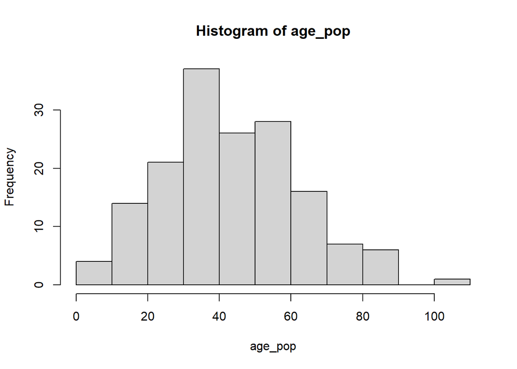

```r
hist(age_pop) # returns a histogram
```

```r
# creating 2 by 80 matrix using the age_pop vector
age_sample_a <-  matrix(data = age_pop,
                      nrow = 80,
                      ncol = 2,
                      byrow = FALSE,
                      dimnames = list(NULL, c("sample_1", "sample_2")))
head(age_sample_a)
```

```
##      sample_1 sample_2
## [1,]       78       51
## [2,]       53       66
## [3,]       19       53
## [4,]       30       37
## [5,]       35       67
## [6,]       68       64
```

```r
# OR
age_sample_b <-  matrix(age_pop, nrow = 80, ncol = 2, dimnames = list(NULL, c("sample_1", "sample_2")))
head(age_sample_b)
```

```
##      sample_1 sample_2
## [1,]       78       51
## [2,]       53       66
## [3,]       19       53
## [4,]       30       37
## [5,]       35       67
## [6,]       68       64
```

```r
head(age_sample_a == age_sample_b)
```

```
##      sample_1 sample_2
## [1,]     TRUE     TRUE
## [2,]     TRUE     TRUE
## [3,]     TRUE     TRUE
## [4,]     TRUE     TRUE
## [5,]     TRUE     TRUE
## [6,]     TRUE     TRUE
```

```r
# OR
age_sample_c <- age_pop
dim(age_sample_c) <- c(80, 2)# If you just want to convert a vector to a matrix, something like
dimnames(age_sample_c) <- list(NULL, c("sample_1", "sample_2"))
head(age_sample_c)
```

```
##      sample_1 sample_2
## [1,]       78       51
## [2,]       53       66
## [3,]       19       53
## [4,]       30       37
## [5,]       35       67
## [6,]       68       64
```

```r
identical(age_sample_a, age_sample_c)
```

```
## [1] TRUE
```

```r
median(age_sample_a)
```

```
## [1] 43
```

```r
median(age_sample_b)
```

```
## [1] 43
```

```r
median(age_sample_c)
```

```
## [1] 43
```

```r
quantile(age_sample_a)
```

```
##     0%    25%    50%    75%   100%
##   0.00  31.00  43.00  56.25 109.00
```

```r
quantile(age_sample_a, c(.33, .66, .99))
```

```
##   33%   66%   99%
## 35.47 51.94 87.41
```

```r
range(age_sample_b)
```

```
## [1]   0 109
```

```r
summary(age_sample_c)
```

```
##     sample_1        sample_2
##  Min.   : 0.00   Min.   :  3.00
##  1st Qu.:33.75   1st Qu.: 29.50
##  Median :43.00   Median : 40.50
##  Mean   :44.27   Mean   : 43.35
##  3rd Qu.:56.25   3rd Qu.: 56.50
##  Max.   :87.00   Max.   :109.00
```

```r
?matrix
?rnorm
?round
?length
?mean
?sd
?max
?min
?hist
?identical
?median
?quantile
?range
?summary
```

Formas alternativas de criar matrizes usando cbind(), rbind() e dim()

```r
population <- c(144549, 174030, 175136, 175478, 181494, 205094, 206479, 237591, 302295, 377835, 547733)
areakm2 <- c(26.5, 70.2, 23.8, 62.4, 183.4, 167.2, 97.4, 41.4, 168.5, 319.2, 100.0)
city_names <- c("Odivelas", "Almada", "Amadora", "Matosinhos", "Braga", "Loures", "Cascais", "Porto", "Vila Nova de Gaia", "Sintra", "Lisboa")

# bind by column - cbind()
cities <- cbind(population, areakm2) # bind by column
class(cities)
```

```
## [1] "matrix" "array"
```

```r
cities
```

```
##       population areakm2
##  [1,]     144549    26.5
##  [2,]     174030    70.2
##  [3,]     175136    23.8
##  [4,]     175478    62.4
##  [5,]     181494   183.4
##  [6,]     205094   167.2
##  [7,]     206479    97.4
##  [8,]     237591    41.4
##  [9,]     302295   168.5
## [10,]     377835   319.2
## [11,]     547733   100.0
```

```r
rownames(cities) <- city_names
cities
```

```
##                   population areakm2
## Odivelas              144549    26.5
## Almada                174030    70.2
## Amadora               175136    23.8
## Matosinhos            175478    62.4
## Braga                 181494   183.4
## Loures                205094   167.2
## Cascais               206479    97.4
## Porto                 237591    41.4
## Vila Nova de Gaia     302295   168.5
## Sintra                377835   319.2
## Lisboa                547733   100.0
```

```r
colnames(cities) <- c("pop", "km2") # changes column name
cities
```

```
##                      pop   km2
## Odivelas          144549  26.5
## Almada            174030  70.2
## Amadora           175136  23.8
## Matosinhos        175478  62.4
## Braga             181494 183.4
## Loures            205094 167.2
## Cascais           206479  97.4
## Porto             237591  41.4
## Vila Nova de Gaia 302295 168.5
## Sintra            377835 319.2
## Lisboa            547733 100.0
```

```r
#  bind by row - rbind()
cities <- rbind(population, areakm2)
class(cities)
```

```
## [1] "matrix" "array"
```

```r
cities
```

```
##                [,1]     [,2]     [,3]     [,4]     [,5]     [,6]     [,7]
## population 144549.0 174030.0 175136.0 175478.0 181494.0 205094.0 206479.0
## areakm2        26.5     70.2     23.8     62.4    183.4    167.2     97.4
##                [,8]     [,9]    [,10]  [,11]
## population 237591.0 302295.0 377835.0 547733
## areakm2        41.4    168.5    319.2    100
```

```r
colnames(cities) <- city_names
cities
```

```
##            Odivelas   Almada  Amadora Matosinhos    Braga   Loures  Cascais
## population 144549.0 174030.0 175136.0   175478.0 181494.0 205094.0 206479.0
## areakm2        26.5     70.2     23.8       62.4    183.4    167.2     97.4
##               Porto Vila Nova de Gaia   Sintra Lisboa
## population 237591.0          302295.0 377835.0 547733
## areakm2        41.4             168.5    319.2    100
```

```r
# create a matrix by setting its dimension - dim()
cities <- c(144549, 174030, 175136, 175478, 181494, 205094, 206479, 237591, 302295, 377835, 547733, 26.5, 70.2, 23.8, 62.4, 183.4, 167.2, 97.4, 41.4, 168.5, 319.2, 100.0)
dim(cities) <- c(11,2)
cities
```

```
##         [,1]  [,2]
##  [1,] 144549  26.5
##  [2,] 174030  70.2
##  [3,] 175136  23.8
##  [4,] 175478  62.4
##  [5,] 181494 183.4
##  [6,] 205094 167.2
##  [7,] 206479  97.4
##  [8,] 237591  41.4
##  [9,] 302295 168.5
## [10,] 377835 319.2
## [11,] 547733 100.0
```

```r
colnames(cities) <- c("population", "areakm2")
rownames(cities) <- c("Odivelas", "Almada", "Amadora", "Matosinhos", "Braga", "Loures", "Cascais", "Porto", "Vila Nova de Gaia", "Sintra", "Lisboa")
cities
```

```
##                   population areakm2
## Odivelas              144549    26.5
## Almada                174030    70.2
## Amadora               175136    23.8
## Matosinhos            175478    62.4
## Braga                 181494   183.4
## Loures                205094   167.2
## Cascais               206479    97.4
## Porto                 237591    41.4
## Vila Nova de Gaia     302295   168.5
## Sintra                377835   319.2
## Lisboa                547733   100.0
```

## Acesso a elementos de matrizes

Podemos aceder a elementos de matrizes utilizando o índice com parentesis retos - x[i, j]. Os vetores numéricos i e j identificam, respetivamente, as linhas e as colunas da matriz x.

```r
library(datasets) # loads datasets
data(women) # loads women
women <- as.matrix(women) # coerces women to a matrix
women # view matrix
```

```
##       height weight
##  [1,]     58    115
##  [2,]     59    117
##  [3,]     60    120
##  [4,]     61    123
##  [5,]     62    126
##  [6,]     63    129
##  [7,]     64    132
##  [8,]     65    135
##  [9,]     66    139
## [10,]     67    142
## [11,]     68    146
## [12,]     69    150
## [13,]     70    154
## [14,]     71    159
## [15,]     72    164
```

```r
# ?women
class(women) # inspects class
```

```
## [1] "matrix" "array"
```

```r
str(women) # inspects structure
```

```
##  num [1:15, 1:2] 58 59 60 61 62 63 64 65 66 67 ...
##  - attr(*, "dimnames")=List of 2
##   ..$ : NULL
##   ..$ : chr [1:2] "height" "weight"
```

```r
storage.mode(women) # inspects the type of data
```

```
## [1] "double"
```

```r
dim(women)
```

```
## [1] 15  2
```

```r
colnames(women)
```

```
## [1] "height" "weight"
```

```r
women[c(1:3), 2]  # select rows from 1 to 3 and columns 2
```

```
## [1] 115 117 120
```

```r
women[c(1:3, 13:15), ] # leaving column field blank will select entire columns
```

```
##      height weight
## [1,]     58    115
## [2,]     59    117
## [3,]     60    120
## [4,]     70    154
## [5,]     71    159
## [6,]     72    164
```

```r
women[ , -1] # select all columns except first
```

```
##  [1] 115 117 120 123 126 129 132 135 139 142 146 150 154 159 164
```

```r
women8 <- women[8,] # notice the result will be given as a vecto if the matrix returned by indexing is a row matrix or a column matrix
women8
```

```
## height weight
##     65    135
```

```r
class(women8)
```

```
## [1] "numeric"
```

```r
women8 <- women[8, , drop=FALSE] # A matrix structure can be preserved by using the argument drop = FALSE while indexing
women8
```

```
##      height weight
## [1,]     65    135
```

```r
class(women8)
```

```
## [1] "matrix" "array"
```

```r
women[1:20] # It is possible to index a matrix with a single vector.
```

```
##  [1]  58  59  60  61  62  63  64  65  66  67  68  69  70  71  72 115 117 120 123
## [20] 126
```

```r
# While indexing in such a way, it acts like a vector formed by stacking columns of the matrix one after another. The result is returned as a vector.
women[c(1,15,16,30)]
```

```
## [1]  58  72 115 164
```

Usar vetores lógicos para indexar matrizes

```r
#Two logical vectors can be used to index a matrix. In such situation, rows and columns where the value is TRUE is returned. These indexing vectors are recycled if necessary and can be mixed with integer vectors.

i <- rep(c(TRUE, FALSE, FALSE), 5)
i
```

```
##  [1]  TRUE FALSE FALSE  TRUE FALSE FALSE  TRUE FALSE FALSE  TRUE FALSE FALSE
## [13]  TRUE FALSE FALSE
```

```r
j <- c(FALSE, TRUE)
j
```

```
## [1] FALSE  TRUE
```

```r
women[i, j]
```

```
## [1] 115 123 132 142 154
```

```r
women[c(TRUE,FALSE), 1] # the 2-element logical vector is recycled to cover the entire matrix and the matrix is treated as a vector column wise
```

```
## [1] 58 60 62 64 66 68 70 72
```

```r
women[women>66] # select elements greater than 66 - again the matrix is vectorized column wise
```

```
##  [1]  67  68  69  70  71  72 115 117 120 123 126 129 132 135 139 142 146 150 154
## [20] 159 164
```

```r
women[women%%2 == 0] # select even elements
```

```
##  [1]  58  60  62  64  66  68  70  72 120 126 132 142 146 150 154 164
```

```r
women[ , "height"] # indexing with character vector is also possible for matrix with named row or column
```

```
##  [1] 58 59 60 61 62 63 64 65 66 67 68 69 70 71 72
```

```r
women[c(FALSE,TRUE,TRUE) , "height"]
```

```
##  [1] 59 60 62 63 65 66 68 69 71 72
```

```r
?class
?str
?storage.mode
?dim
?colnames
?rep
```

## Manipular e apagar matrizes

Podemos combinar o operador de atribuição (<-) com diferentes métodos de indexação para modificar elementos de uma matriz

```r
library(datasets) # loads datasets
data(women)
women <- as.matrix(women) # loads women and coerces to a matrix
women # view matrix
```

```
##       height weight
##  [1,]     58    115
##  [2,]     59    117
##  [3,]     60    120
##  [4,]     61    123
##  [5,]     62    126
##  [6,]     63    129
##  [7,]     64    132
##  [8,]     65    135
##  [9,]     66    139
## [10,]     67    142
## [11,]     68    146
## [12,]     69    150
## [13,]     70    154
## [14,]     71    159
## [15,]     72    164
```

```r
women[2, 2] <-  118 # assigns 118 to women row 2, column 2
women
```

```
##       height weight
##  [1,]     58    115
##  [2,]     59    118
##  [3,]     60    120
##  [4,]     61    123
##  [5,]     62    126
##  [6,]     63    129
##  [7,]     64    132
##  [8,]     65    135
##  [9,]     66    139
## [10,]     67    142
## [11,]     68    146
## [12,]     69    150
## [13,]     70    154
## [14,]     71    159
## [15,]     72    164
```

```r
selection <- women[, 2] > 150 # selects elements in 2nd column higher than 150
selection
```

```
##  [1] FALSE FALSE FALSE FALSE FALSE FALSE FALSE FALSE FALSE FALSE FALSE FALSE
## [13]  TRUE  TRUE  TRUE
```

```r
women[selection, 2] <-  160
women
```

```
##       height weight
##  [1,]     58    115
##  [2,]     59    118
##  [3,]     60    120
##  [4,]     61    123
##  [5,]     62    126
##  [6,]     63    129
##  [7,]     64    132
##  [8,]     65    135
##  [9,]     66    139
## [10,]     67    142
## [11,]     68    146
## [12,]     69    150
## [13,]     70    160
## [14,]     71    160
## [15,]     72    160
```

```r
# OR
selection <- which(women[,2] > 150)
selection
```

```
## [1] 13 14 15
```

```r
women[selection, 2] <- 160 # assigns 160 to weight when weight higher than 150
women
```

```
##       height weight
##  [1,]     58    115
##  [2,]     59    118
##  [3,]     60    120
##  [4,]     61    123
##  [5,]     62    126
##  [6,]     63    129
##  [7,]     64    132
##  [8,]     65    135
##  [9,]     66    139
## [10,]     67    142
## [11,]     68    146
## [12,]     69    150
## [13,]     70    160
## [14,]     71    160
## [15,]     72    160
```

```r
women <- women [c(-13:-15),] # deletes row 13 to 15
women
```

```
##       height weight
##  [1,]     58    115
##  [2,]     59    118
##  [3,]     60    120
##  [4,]     61    123
##  [5,]     62    126
##  [6,]     63    129
##  [7,]     64    132
##  [8,]     65    135
##  [9,]     66    139
## [10,]     67    142
## [11,]     68    146
## [12,]     69    150
```

```r
women <- women[,-2] # deletes column 2
women
```

```
##  [1] 58 59 60 61 62 63 64 65 66 67 68 69
```

```r
women <- NULL # eliminates women
women
```

[output not shown]

```r
data(women); women <- as.matrix(women)
women_transp <- t(women) # transposes columns to rows
women_transp
```

```
##        [,1] [,2] [,3] [,4] [,5] [,6] [,7] [,8] [,9] [,10] [,11] [,12] [,13]
## height   58   59   60   61   62   63   64   65   66    67    68    69    70
## weight  115  117  120  123  126  129  132  135  139   142   146   150   154
##        [,14] [,15]
## height    71    72
## weight   159   164
```

```r
data(women); women <- as.matrix(women)
women[,1]
```

```
##  [1] 58 59 60 61 62 63 64 65 66 67 68 69 70 71 72
```

```r
height_cm <- women[, "height"]*2.54 # creates a new vector, height_cm (1 inch = 2.54 centimeters)
height_cm
```

```
##  [1] 147.32 149.86 152.40 154.94 157.48 160.02 162.56 165.10 167.64 170.18
## [11] 172.72 175.26 177.80 180.34 182.88
```

```r
women[,2]
```

```
##  [1] 115 117 120 123 126 129 132 135 139 142 146 150 154 159 164
```

```r
weight_kg <- women[, "weight"]*0.45359237 # creates a new vector, weight_kg (1 pound = 0.45359237 kg)
weight_kg
```

```
##  [1] 52.16312 53.07031 54.43108 55.79186 57.15264 58.51342 59.87419 61.23497
##  [9] 63.04934 64.41012 66.22449 68.03886 69.85322 72.12119 74.38915
```

```r
women <- cbind(women, height_cm, weight_kg) # adds the new vectors to women
women
```

```
##       height weight height_cm weight_kg
##  [1,]     58    115    147.32  52.16312
##  [2,]     59    117    149.86  53.07031
##  [3,]     60    120    152.40  54.43108
##  [4,]     61    123    154.94  55.79186
##  [5,]     62    126    157.48  57.15264
##  [6,]     63    129    160.02  58.51342
##  [7,]     64    132    162.56  59.87419
##  [8,]     65    135    165.10  61.23497
##  [9,]     66    139    167.64  63.04934
## [10,]     67    142    170.18  64.41012
## [11,]     68    146    172.72  66.22449
## [12,]     69    150    175.26  68.03886
## [13,]     70    154    177.80  69.85322
## [14,]     71    159    180.34  72.12119
## [15,]     72    164    182.88  74.38915
```

```r
summary(women)
```

```
##      height         weight        height_cm       weight_kg
##  Min.   :58.0   Min.   :115.0   Min.   :147.3   Min.   :52.16
##  1st Qu.:61.5   1st Qu.:124.5   1st Qu.:156.2   1st Qu.:56.47
##  Median :65.0   Median :135.0   Median :165.1   Median :61.23
##  Mean   :65.0   Mean   :136.7   Mean   :165.1   Mean   :62.02
##  3rd Qu.:68.5   3rd Qu.:148.0   3rd Qu.:174.0   3rd Qu.:67.13
##  Max.   :72.0   Max.   :164.0   Max.   :182.9   Max.   :74.39
```

```r
cor(women[, 3], women[, 4])
```

```
## [1] 0.9954948
```

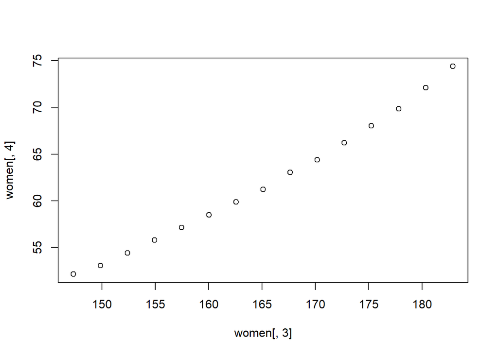

```r
plot(women[, 3], women[, 4])
```

# 5. Exercício 3: Cidades II